# GGR376 - Lab 1 - Tutorial

Regression

#### Open a new R Script in RStudio

Scripts must be saved with the .R extension

```r
library(tidyverse)
```

### Reading Data

#### Files on your hard drive:

- Navigate to: https://raw.githubusercontent.com/tidyverse/readr/master/inst/extdata/mtcars.csv
- Download the file with “Save As”
  - Note where the file is saved

```r
# Read in our csv file
mtcars <- read_csv("//Users/matthewadams/Desktop/mtcars.csv")
# View the data
mtcars
```

| mpg | cyl | disp | hp | drat | wt | qsec | vs | am | gear | carb |
| --- | --- | --- | --- | --- | --- | --- | --- | --- | --- | --- |
| 21.0 | 6 | 160.0 | 110 | 3.90 | 2.620 | 16.46 | 0 | 1 | 4 | 4 |
| 21.0 | 6 | 160.0 | 110 | 3.90 | 2.875 | 17.02 | 0 | 1 | 4 | 4 |
| 22.8 | 4 | 108.0 | 93 | 3.85 | 2.320 | 18.61 | 1 | 1 | 4 | 1 |
| 21.4 | 6 | 258.0 | 110 | 3.08 | 3.215 | 19.44 | 1 | 0 | 3 | 1 |
| 18.7 | 8 | 360.0 | 175 | 3.15 | 3.440 | 17.02 | 0 | 0 | 3 | 2 |
| 18.1 | 6 | 225.0 | 105 | 2.76 | 3.460 | 20.22 | 1 | 0 | 3 | 1 |
| 14.3 | 8 | 360.0 | 245 | 3.21 | 3.570 | 15.84 | 0 | 0 | 3 | 4 |
| 24.4 | 4 | 146.7 | 62 | 3.69 | 3.190 | 20.00 | 1 | 0 | 4 | 2 |
| 22.8 | 4 | 140.8 | 95 | 3.92 | 3.150 | 22.90 | 1 | 0 | 4 | 2 |
| 19.2 | 6 | 167.6 | 123 | 3.92 | 3.440 | 18.30 | 1 | 0 | 4 | 4 |

[output cut: 22 more lines]

#### Files from the internet

Read in files stored on the internet using the url.

```r
mtcars_url <- read_csv(
  "https://raw.githubusercontent.com/tidyverse/readr/master/inst/extdata/mtcars.csv")
```

View the data using RStudio’s View()

```r
View(mtcars_url)
```

Read the help file for the read_csv() function, using the ? or help() function.

#### Examine the environment panel in RStudio

Remove both versions of the mtcars data

```r
remove(mtcars, mtcars_url)
```

## Regression Exercise

The TA will walk you through the process of regression and spatial regression. This tutorial was inspired by Roger Bivand’s Spatial Regression examples on rspatial.org. Your assignment will require you to produce a similar work using Canadian Census Data.

The data for this tutorial is stored in three files on a GitHub account. It is California house price data from the 2000 Census, and the files include:

- Average house price per census tract file
- Census tract attributes file
- Census tract polygon file.

They all share a GEOID variable, which can be used to join the files.

### Merging Tables

Read in the housing price file and the attributes file.

| ID | TRACT | GEOID | label | nhousingUn | nMobileHom | yearBuilt | nBadPlumbi | nBadKitche | nRooms | nBedrooms | medHHinc | Population | MedianAge | PopInHouse | nHousehold | Families |
| --- | --- | --- | --- | --- | --- | --- | --- | --- | --- | --- | --- | --- | --- | --- | --- | --- |
| 1 | 0001 | 6005000100 | Census Tract 1, Amador County, California | 3847 | 199 | 1978 | 79 | 66 | 5.2 | 2.396153 | 39417 | 6076 | 49.8 | 6076 | 2680 | 1932 |
| 2 | 0001 | 6011000100 | Census Tract 1, Colusa County, California | 1471 | 162 | 1971 | 27 | 23 | 4.8 | 2.208022 | 36514 | 4433 | 29.6 | 4428 | 1344 | 1058 |
| 3 | 0001 | 6019000100 | Census Tract 1, Fresno County, California | 496 | 0 | 1955 | 0 | 185 | 1.7 | 0.649194 | 8498 | 2755 | 32.7 | 416 | 367 | 23 |
| 4 | 0001 | 6023000100 | Census Tract 1, Humboldt County, California | 2053 | 6 | 1939 | 34 | 22 | 3.4 | 1.553824 | 19183 | 4267 | 30.3 | 4061 | 1917 | 791 |
| 5 | 0001 | 6027000100 | Census Tract 1, Inyo County, California | 1271 | 770 | 1980 | 0 | 0 | 5.5 | 2.719119 | 39205 | 2812 | 44.5 | 2810 | 1192 | 827 |
| 6 | 0001 | 6031000100 | Census Tract 1, Kings County, California | 1159 | 83 | 1960 | 6 | 3 | 5.5 | 2.597929 | 36391 | 3368 | 34.3 | 3358 | 1093 | 879 |
| 7 | 0001 | 6033000100 | Census Tract 1, Lake County, California | 1530 | 398 | 1973 | 62 | 59 | 4.7 | 2.205882 | 30481 | 2796 | 42.4 | 2738 | 1125 | 752 |
| 8 | 0001 | 6043000100 | Census Tract 1, Mariposa County, California | 2996 | 859 | 1977 | 48 | 47 | 4.9 | 2.236649 | 30645 | 6082 | 43.6 | 5810 | 2545 | 1608 |
| 9 | 0001 | 6047000100 | Census Tract 1, Merced County, California | 429 | 131 | 1972 | 0 | 0 | 4.8 | 2.361305 | 31250 | 1166 | 30.6 | 1160 | 388 | 281 |
| 10 | 0001 | 6049000100 | Census Tract 1, Modoc County, California | 1681 | 238 | 1964 | 21 | 22 | 5.0 | 2.381321 | 24784 | 3506 | 39.7 | 3426 | 1440 | 932 |

[output cut: 990 more lines]

The tables need to be joined. The dplyr package includes a functions for joining data.frames/tibbles. See the Data Wrangling Cheat Sheet for visual examples: https://www.rstudio.com/wp-content/uploads/2015/02/data-wrangling-cheatsheet.pdf

- dplyr::left_join(), Join matching rows from b to a.
  - NAs possible
- dplyr::right_join(), Join matching rows from a to b.
  - NAs possible
- dplyr::inner_join(), Join data, retain only rows in both sets
  - No NAs, rows excluded that create a NA
- dplyr::full_join(), Join data, retain all values, all rows.
  - NAs possible

Rows with missing values will need to be excluded in the regression model. Use an inner_join() so no NAs will be introduced.

```r
california_cts <- inner_join(house_prices, house_attributes, by = "GEOID")
california_cts
```

| GEOID | houseValue | ID | TRACT | label | nhousingUn | nMobileHom | yearBuilt | nBadPlumbi | nBadKitche | nRooms | nBedrooms | medHHinc | Population | MedianAge | PopInHouse | nHousehold | Families |
| --- | --- | --- | --- | --- | --- | --- | --- | --- | --- | --- | --- | --- | --- | --- | --- | --- | --- |
| 6005000100 | 143000 | 1 | 0001 | Census Tract 1, Amador County, California | 3847 | 199 | 1978 | 79 | 66 | 5.2 | 2.396153 | 39417 | 6076 | 49.8 | 6076 | 2680 | 1932 |
| 6011000100 | 108200 | 2 | 0001 | Census Tract 1, Colusa County, California | 1471 | 162 | 1971 | 27 | 23 | 4.8 | 2.208022 | 36514 | 4433 | 29.6 | 4428 | 1344 | 1058 |
| 6019000100 | 0 | 3 | 0001 | Census Tract 1, Fresno County, California | 496 | 0 | 1955 | 0 | 185 | 1.7 | 0.649194 | 8498 | 2755 | 32.7 | 416 | 367 | 23 |
| 6023000100 | 99300 | 4 | 0001 | Census Tract 1, Humboldt County, California | 2053 | 6 | 1939 | 34 | 22 | 3.4 | 1.553824 | 19183 | 4267 | 30.3 | 4061 | 1917 | 791 |
| 6027000100 | 195800 | 5 | 0001 | Census Tract 1, Inyo County, California | 1271 | 770 | 1980 | 0 | 0 | 5.5 | 2.719119 | 39205 | 2812 | 44.5 | 2810 | 1192 | 827 |
| 6031000100 | 145400 | 6 | 0001 | Census Tract 1, Kings County, California | 1159 | 83 | 1960 | 6 | 3 | 5.5 | 2.597929 | 36391 | 3368 | 34.3 | 3358 | 1093 | 879 |
| 6033000100 | 102800 | 7 | 0001 | Census Tract 1, Lake County, California | 1530 | 398 | 1973 | 62 | 59 | 4.7 | 2.205882 | 30481 | 2796 | 42.4 | 2738 | 1125 | 752 |
| 6043000100 | 144400 | 8 | 0001 | Census Tract 1, Mariposa County, California | 2996 | 859 | 1977 | 48 | 47 | 4.9 | 2.236649 | 30645 | 6082 | 43.6 | 5810 | 2545 | 1608 |
| 6047000100 | 98600 | 9 | 0001 | Census Tract 1, Merced County, California | 429 | 131 | 1972 | 0 | 0 | 4.8 | 2.361305 | 31250 | 1166 | 30.6 | 1160 | 388 | 281 |
| 6049000100 | 65700 | 10 | 0001 | Census Tract 1, Modoc County, California | 1681 | 238 | 1964 | 21 | 22 | 5.0 | 2.381321 | 24784 | 3506 | 39.7 | 3426 | 1440 | 932 |

[output cut: 990 more lines]

Another file contains attribute definitions. Read in and store as a tibble.

```r
variable_attributes <- read_csv(
  "https://raw.githubusercontent.com/gisUTM/GGR376/master/Lab_1/Tutorial/Attribute_Definitions.txt")
variable_attributes
```

| variable | explanation |
| --- | --- |
| nhousingUn | number of housing units |
| nMobileHom | number of mobile homes |
| nBadPlumbi | number of houses with incomplete plumbing |
| nBadKitche | number of houses with incomplete kitchens |
| Population | total population |
| PopInHouse | number of persons living in households |
| nHousehold | number of households |
| Families | number of families |
| houseValue | value of the house |
| yearBuilt | year house was built |

[output cut: 4 more lines]

### Data Management

1. Split the label variable into three variables:
   1. CT
   2. County
   3. State
2. Remove any extra spaces before or after a county name, which can occur when splitting strings.
3. Filter County == “San Diego County”

```r
san_diego <- california_cts%>%
  separate(label, sep = ",", into = c("CT", "County", "State"))%>% # Split
  mutate(County = str_trim(County, side = "both"))%>% # Remove
  filter(County == "San Diego County") # Filter
san_diego
```

| GEOID | houseValue | ID | TRACT | CT | County | State | nhousingUn | nMobileHom | yearBuilt | nBadPlumbi | nBadKitche | nRooms | nBedrooms | medHHinc | Population | MedianAge | PopInHouse | nHousehold | Families |
| --- | --- | --- | --- | --- | --- | --- | --- | --- | --- | --- | --- | --- | --- | --- | --- | --- | --- | --- | --- |
| 6073000100 | 581000 | 15 | 0001 | Census Tract 1 | San Diego County | California | 1356 | 0 | 1939 | 0 | 6 | 6.5 | 3.248525 | 84618 | 3024 | 46.9 | 3018 | 1298 | 875 |
| 6073000200 | 362600 | 74 | 0002 | Census Tract 2 | San Diego County | California | 3371 | 0 | 1954 | 11 | 23 | 4.2 | 1.867992 | 48780 | 5984 | 39.9 | 5887 | 3241 | 1194 |
| 6073000300 | 299600 | 113 | 0003 | Census Tract 3 | San Diego County | California | 2933 | 0 | 1965 | 8 | 12 | 3.4 | 1.526083 | 37444 | 4446 | 39.4 | 4278 | 2783 | 592 |
| 6073000400 | 309600 | 151 | 0004 | Census Tract 4 | San Diego County | California | 2208 | 0 | 1970 | 0 | 0 | 3.1 | 1.328351 | 36717 | 3466 | 33.9 | 3185 | 2136 | 363 |
| 6073000500 | 320800 | 187 | 0005 | Census Tract 5 | San Diego County | California | 1729 | 0 | 1949 | 8 | 12 | 4.0 | 1.757085 | 42711 | 2756 | 37.7 | 2756 | 1662 | 456 |
| 6073000600 | 227600 | 230 | 0006 | Census Tract 6 | San Diego County | California | 1922 | 0 | 1967 | 19 | 5 | 3.4 | 1.488033 | 36088 | 2963 | 37.4 | 2913 | 1844 | 393 |
| 6073000700 | 340200 | 262 | 0007 | Census Tract 7 | San Diego County | California | 2322 | 0 | 1959 | 36 | 35 | 3.6 | 1.496124 | 35129 | 3414 | 39.0 | 3410 | 2291 | 411 |
| 6073000800 | 215600 | 288 | 0008 | Census Tract 8 | San Diego County | California | 2603 | 0 | 1969 | 0 | 0 | 3.4 | 1.578563 | 35771 | 4218 | 36.9 | 4179 | 2466 | 664 |
| 6073000900 | 144700 | 324 | 0009 | Census Tract 9 | San Diego County | California | 3118 | 14 | 1967 | 27 | 15 | 3.2 | 1.286722 | 24494 | 5594 | 32.4 | 5594 | 3033 | 922 |
| 6073001000 | 186300 | 362 | 0010 | Census Tract 10 | San Diego County | California | 2665 | 0 | 1961 | 10 | 22 | 3.6 | 1.538837 | 35110 | 4948 | 33.0 | 4921 | 2589 | 885 |

[output cut: 595 more lines]

### Modify the count variables

Create ratio variables from count variables. Many variables are only dependent on CT population, which won’t be helpful in the linear regression model.

| GEOID | houseValue | ID | TRACT | CT | County | State | nhousingUn | nMobileHom | yearBuilt | nBadPlumbi | nBadKitche | nRooms | nBedrooms | medHHinc | Population | MedianAge | PopInHouse | nHousehold | Families | pMobileHom | pBadPlumbi | pBadKitche |
| --- | --- | --- | --- | --- | --- | --- | --- | --- | --- | --- | --- | --- | --- | --- | --- | --- | --- | --- | --- | --- | --- | --- |
| 6073000100 | 581000 | 15 | 0001 | Census Tract 1 | San Diego County | California | 1356 | 0 | 1939 | 0 | 6 | 6.5 | 3.248525 | 84618 | 3024 | 46.9 | 3018 | 1298 | 875 | 0.000000000 | 0.0000000000 | 0.004424779 |
| 6073000200 | 362600 | 74 | 0002 | Census Tract 2 | San Diego County | California | 3371 | 0 | 1954 | 11 | 23 | 4.2 | 1.867992 | 48780 | 5984 | 39.9 | 5887 | 3241 | 1194 | 0.000000000 | 0.0032631267 | 0.006822901 |
| 6073000300 | 299600 | 113 | 0003 | Census Tract 3 | San Diego County | California | 2933 | 0 | 1965 | 8 | 12 | 3.4 | 1.526083 | 37444 | 4446 | 39.4 | 4278 | 2783 | 592 | 0.000000000 | 0.0027275827 | 0.004091374 |
| 6073000400 | 309600 | 151 | 0004 | Census Tract 4 | San Diego County | California | 2208 | 0 | 1970 | 0 | 0 | 3.1 | 1.328351 | 36717 | 3466 | 33.9 | 3185 | 2136 | 363 | 0.000000000 | 0.0000000000 | 0.000000000 |
| 6073000500 | 320800 | 187 | 0005 | Census Tract 5 | San Diego County | California | 1729 | 0 | 1949 | 8 | 12 | 4.0 | 1.757085 | 42711 | 2756 | 37.7 | 2756 | 1662 | 456 | 0.000000000 | 0.0046269520 | 0.006940428 |
| 6073000600 | 227600 | 230 | 0006 | Census Tract 6 | San Diego County | California | 1922 | 0 | 1967 | 19 | 5 | 3.4 | 1.488033 | 36088 | 2963 | 37.4 | 2913 | 1844 | 393 | 0.000000000 | 0.0098855359 | 0.002601457 |
| 6073000700 | 340200 | 262 | 0007 | Census Tract 7 | San Diego County | California | 2322 | 0 | 1959 | 36 | 35 | 3.6 | 1.496124 | 35129 | 3414 | 39.0 | 3410 | 2291 | 411 | 0.000000000 | 0.0155038760 | 0.015073213 |
| 6073000800 | 215600 | 288 | 0008 | Census Tract 8 | San Diego County | California | 2603 | 0 | 1969 | 0 | 0 | 3.4 | 1.578563 | 35771 | 4218 | 36.9 | 4179 | 2466 | 664 | 0.000000000 | 0.0000000000 | 0.000000000 |
| 6073000900 | 144700 | 324 | 0009 | Census Tract 9 | San Diego County | California | 3118 | 14 | 1967 | 27 | 15 | 3.2 | 1.286722 | 24494 | 5594 | 32.4 | 5594 | 3033 | 922 | 0.004490058 | 0.0086593970 | 0.004810776 |
| 6073001000 | 186300 | 362 | 0010 | Census Tract 10 | San Diego County | California | 2665 | 0 | 1961 | 10 | 22 | 3.6 | 1.538837 | 35110 | 4948 | 33.0 | 4921 | 2589 | 885 | 0.000000000 | 0.0037523452 | 0.008255159 |

[output cut: 595 more lines]

#### Potential Predictors

The tutorial will focus on seven predictor variables:

- yearBuilt
- nRooms
- nBedrooms
- MedianAge
- pMobileHom
- pBadPlumbi
- pBadKitche

Subset the variables we will use in the model

```r
View(sd_house)
```

[output not shown]

#### Review Data Values: e.g. zeros where data should have values.

```r
sd_houses%>%
  summary()
```

```
     GEOID             houseValue        yearBuilt        nRooms        nBedrooms       MedianAge
 Min.   :6.073e+09   Min.   :      0   Min.   :   0   Min.   :0.000   Min.   :0.000   Min.   :15.50
 1st Qu.:6.073e+09   1st Qu.: 160500   1st Qu.:1965   1st Qu.:4.000   1st Qu.:1.918   1st Qu.:30.10
 Median :6.073e+09   Median : 201900   Median :1973   Median :5.000   Median :2.512   Median :34.20
 Mean   :6.073e+09   Mean   : 241147   Mean   :1962   Mean   :4.929   Mean   :2.457   Mean   :34.73
 3rd Qu.:6.073e+09   3rd Qu.: 279400   3rd Qu.:1979   3rd Qu.:5.800   3rd Qu.:2.989   3rd Qu.:38.40
 Max.   :6.073e+09   Max.   :1000001   Max.   :1999   Max.   :9.100   Max.   :4.787   Max.   :77.20

   pMobileHom        pBadPlumbi         pBadKitche
 Min.   :0.00000   Min.   :0.000000   Min.   :0.000000
 1st Qu.:0.00000   1st Qu.:0.000000   1st Qu.:0.000000
 Median :0.00000   Median :0.003309   Median :0.003487
 Mean   :0.04122   Mean   :0.007450   Mean   :0.009425
 3rd Qu.:0.03199   3rd Qu.:0.008509   3rd Qu.:0.008867
 Max.   :0.64592   Max.   :0.268262   Max.   :0.307305
 NA's   :3         NA's   :3          NA's   :3
```

Filter out rows with 0 values for either houseValue, yearBuilt, nRooms, nBedrooms

```r
sd_houses%>%
  summary
```

```
     GEOID             houseValue        yearBuilt        nRooms        nBedrooms       MedianAge
 Min.   :6.073e+09   Min.   :  82000   Min.   :1939   Min.   :1.500   Min.   :0.658   Min.   :15.50
 1st Qu.:6.073e+09   1st Qu.: 162000   1st Qu.:1965   1st Qu.:4.000   1st Qu.:1.922   1st Qu.:30.30
 Median :6.073e+09   Median : 205000   Median :1973   Median :5.000   Median :2.513   Median :34.30
 Mean   :6.073e+09   Mean   : 246027   Mean   :1972   Mean   :4.962   Mean   :2.472   Mean   :34.91
 3rd Qu.:6.073e+09   3rd Qu.: 282100   3rd Qu.:1979   3rd Qu.:5.800   3rd Qu.:2.989   3rd Qu.:38.40
 Max.   :6.073e+09   Max.   :1000001   Max.   :1999   Max.   :9.100   Max.   :4.787   Max.   :77.20
   pMobileHom        pBadPlumbi         pBadKitche
 Min.   :0.00000   Min.   :0.000000   Min.   :0.000000
 1st Qu.:0.00000   1st Qu.:0.000000   1st Qu.:0.000000
 Median :0.00000   Median :0.003382   Median :0.003534
 Mean   :0.04184   Mean   :0.007303   Mean   :0.009029
 3rd Qu.:0.03419   3rd Qu.:0.008511   3rd Qu.:0.008876
 Max.   :0.64592   Max.   :0.268262   Max.   :0.307305
```

### Graphical Analysis Pre-Check

- Scatter plot: Check for linear relationships between predictors and dependent
- Box plot: Outlier check
- Histogram: Check variables for normal distributions

Each plot type will be demonstrated. Then you need to complete the remainder. Base R plots are fine for variable review.

Including mapping = aes(x = yearBuilt, y = houseValue in the ggplot() function removes the need to specify the x and y for each geom added.

##### Scatter Plot ggplot2()

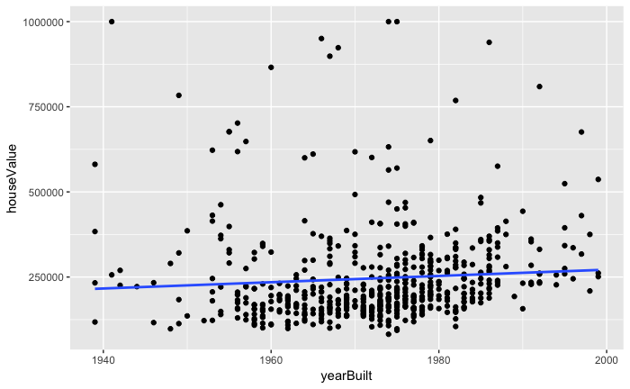

```r
ggplot(data = sd_houses, mapping = aes(x = yearBuilt, y = houseValue))+
  geom_point()+
  geom_smooth(method = "lm", se = F)
```

##### Scatter Plot Base R

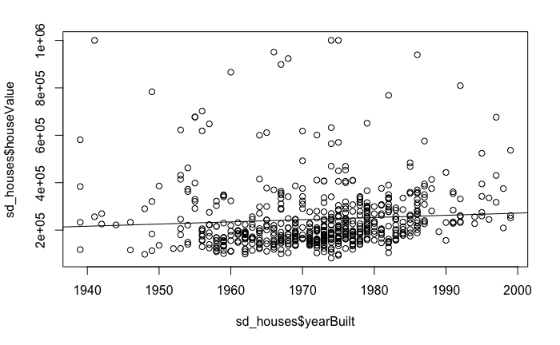

```r
plot(sd_houses$yearBuilt, sd_houses$houseValue)
# To include the regression line, we use abline()
abline(lm(houseValue~yearBuilt, data = sd_houses))
```

##### Box plot ggplot2()

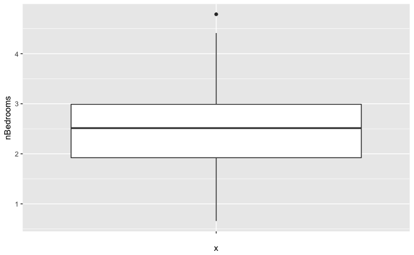

```r
ggplot(data = sd_houses)+
  geom_boxplot( mapping = aes(x = "", y = nBedrooms)) # Note: x = ""
```

```r
# In this example the value is not extreme, it is fine to leave it.
```

##### Box plot base r

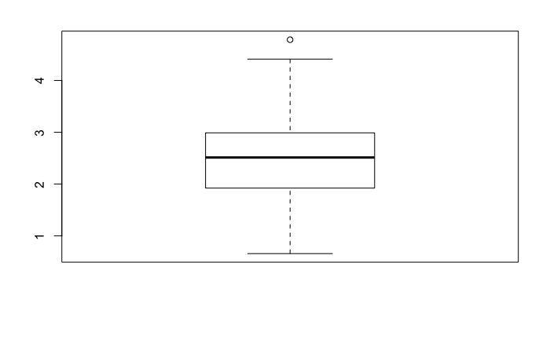

```r
boxplot(sd_houses$nBedrooms) # Much easier to work with base R here.
```

##### Histogram in ggplot2

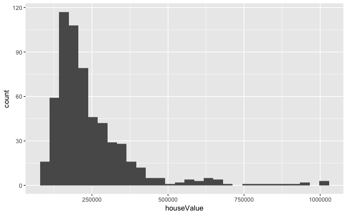

```r
ggplot(sd_houses)+
  geom_histogram(mapping = aes(x = houseValue))
```

```r
# Warning can be ignored because this plot is temporary
```

#### Histogram in base r

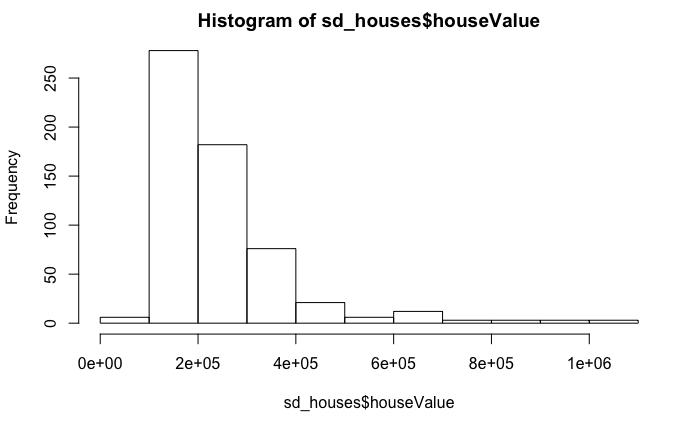

```r
hist(sd_houses$houseValue)
```

#### Normality test - shapiro.test()

The null hypothesis of this test is that the data are normal.

```r
sd_houses%>%
  # We can ignore GEOID in this test
  select(-GEOID)%>%

  # Map allows us to apply a function to each variable in our tibble
  map(shapiro.test)
```

[output not shown]

#### Data Transformations

First data transformation for houseValue

[figure not shown]

#### Chained mutations

```r
sd_trans <- sd_houses%>%
  mutate(logValue = log(houseValue+1))%>%
  mutate(logMobile = log(pMobileHom+1))%>%
  mutate(logPlumb = log(pBadPlumbi+1))%>%
  mutate(logKitchen = log(pBadKitche+1))%>%
  select(-houseValue, -pMobileHom, -pBadPlumbi, -pBadKitche)
```

#### Correlation Matrix

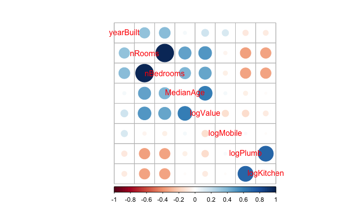

#### Variable Selection

In the tutorial a manual approach to variable selection will be applied. - Begin with the strongest predictor variable based on the correlation plot, which appears to be median age. - Add variables and check how they affect the model.

```r
model_1 <- lm(logValue ~ MedianAge, data = sd_trans)
```

Take a look at the model.

```r
model_1
```

```
Call:
lm(formula = logValue ~ MedianAge, data = sd_trans)

Coefficients:
(Intercept)    MedianAge
   11.01352      0.03698
```

Use the summary function

```r
summary(model_1)
```

```
Call:
lm(formula = logValue ~ MedianAge, data = sd_trans)

Residuals:
     Min       1Q   Median       3Q      Max
-2.02617 -0.21708 -0.05353  0.17357  1.15186

Coefficients:
             Estimate Std. Error t value Pr(>|t|)
(Intercept) 11.013520   0.071454  154.13   <2e-16 ***
MedianAge    0.036981   0.002005   18.44   <2e-16 ***
---
Signif. codes:  0 ‘***’ 0.001 ‘**’ 0.01 ‘*’ 0.05 ‘.’ 0.1 ‘ ’ 1

Residual standard error: 0.3474 on 591 degrees of freedom
Multiple R-squared:  0.3652,    Adjusted R-squared:  0.3641
F-statistic:   340 on 1 and 591 DF,  p-value: < 2.2e-16
```

The predictor variable, MedianAge, is statistically significant and is the the overall model. The adjusted R-Squared is 0.36, thus the model’s explains 36% of the variation in the dependent variable.

### Recall Assumptions of the model

1. The mean of the residuals is zero
2. Homoscedasticity of residuals or equal variance
3. Multicollinearity
4. The independent variables and residuals are uncorrelated
5. The variability in X values is positive
6. The number of observations must be greater than number of independent
7. Normality of residuals
8. No auto-correlation of residuals

Without any work we know we have satisfied: 5. The variability in X values is positive + Which is based on when we looked at the ranges of all our our variables.

6. The number of observations must be greater than number of independent
   - We have hundreds of observations (rows) in our dataset.

#### The mean of the residuals is zero

```r
# Mean of the residuals is zero
mean(model_1$residuals)
```

```
[1] -3.325557e-18
```

R by default uses scientific notation. To change this run the following command.

```r
options(scipen=999)
```

Now call the function.

```r
mean(model_1$residuals)
```

```
[1] -0.000000000000000003325557
```

To set it back

```r
options(scipen=0)
mean(model_1$residuals)
```

```
[1] -3.325557e-18
```

Remove the scientific notation and re-run the summary for model_1

```r
options(scipen=999)
# Go back and run the summary of your model_1
```

#### Homoscedasticity of residuals or equal variance

Check for a flat line in the first and third plots.

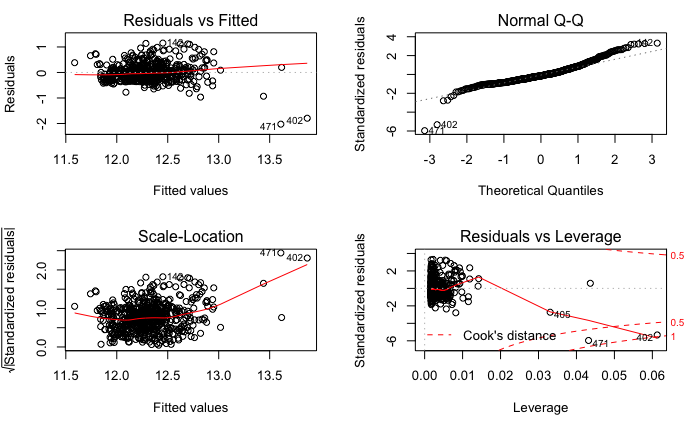

```r
par(mfrow=c(2,2)) # set 2 rows and 2 column plot layout in base R
plot(model_1)
```

Observations 402, 405 and 471 are causing some issues in the model. Take a look at their values using the slice function.

```r
sd_trans%>%
  # Slice the two rows using a vector c(402, 471)
  slice(c(402, 471, 405))
```

| GEOID | yearBuilt | nRooms | nBedrooms | MedianAge | logValue | logMobile | logPlumb | logKitchen |
| --- | --- | --- | --- | --- | --- | --- | --- | --- |
| 6073017014 | 1969 | 4.9 | 1.987246 | 77.2 | 12.07483 | 0.000000000 | 0.002894358 | 0.06018122 |
| 6073018512 | 1974 | 4.3 | 1.929669 | 70.2 | 11.58339 | 0.000000000 | 0.003719205 | 0.00000000 |
| 6073017019 | 1979 | 5.7 | 2.835586 | 65.6 | 12.50729 | 0.002570696 | 0.004174031 | 0.00000000 |

```r
nrow(sd_trans_sub)
```

```
[1] 590
```

Fit the model with the subset data.

```r
model_2 <- lm(logValue ~ MedianAge, sd_trans_sub) # Note the name change
summary(model_2)
```

```
Call:
lm(formula = logValue ~ MedianAge, data = sd_trans_sub)

Residuals:
    Min      1Q  Median      3Q     Max
-1.0704 -0.2145 -0.0535  0.1567  1.1323

Coefficients:
             Estimate Std. Error t value            Pr(>|t|)
(Intercept) 10.785477   0.071127  151.64 <0.0000000000000002 ***
MedianAge    0.043779   0.002012   21.76 <0.0000000000000002 ***
---
Signif. codes:  0 ‘***’ 0.001 ‘**’ 0.01 ‘*’ 0.05 ‘.’ 0.1 ‘ ’ 1

Residual standard error: 0.3244 on 588 degrees of freedom
Multiple R-squared:  0.4461,    Adjusted R-squared:  0.4452
F-statistic: 473.6 on 1 and 588 DF,  p-value: < 0.00000000000000022
```

Plot the assesment graphics

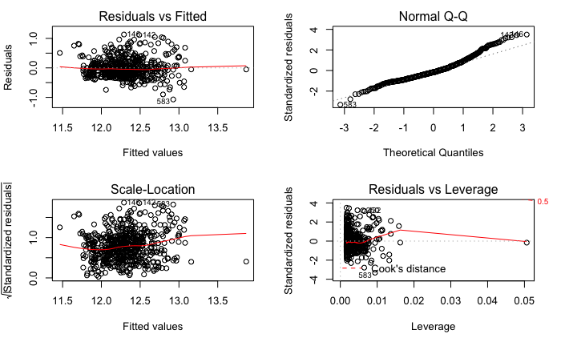

```r
par(mfrow=c(2,2)) # set 2 rows and 2 column plot layout
plot(model_2)
```

Add a second variable to the model. - nBedrooms

```r
model_3 <- lm(logValue ~ MedianAge + nBedrooms, data = sd_trans_sub)
summary(model_3) # The Adj.R.SQ increased by ~0.04
```

```
Call:
lm(formula = logValue ~ MedianAge + nBedrooms, data = sd_trans_sub)

Residuals:
     Min       1Q   Median       3Q      Max
-0.93116 -0.21283 -0.05542  0.14646  1.10212

Coefficients:
             Estimate Std. Error t value             Pr(>|t|)
(Intercept) 10.675934   0.070915 150.545 < 0.0000000000000002 ***
MedianAge    0.037570   0.002174  17.278 < 0.0000000000000002 ***
nBedrooms    0.131467   0.020523   6.406       0.000000000307 ***
---
Signif. codes:  0 ‘***’ 0.001 ‘**’ 0.01 ‘*’ 0.05 ‘.’ 0.1 ‘ ’ 1

Residual standard error: 0.3139 on 587 degrees of freedom
Multiple R-squared:  0.4823,    Adjusted R-squared:  0.4806
F-statistic: 273.5 on 2 and 587 DF,  p-value: < 0.00000000000000022
```

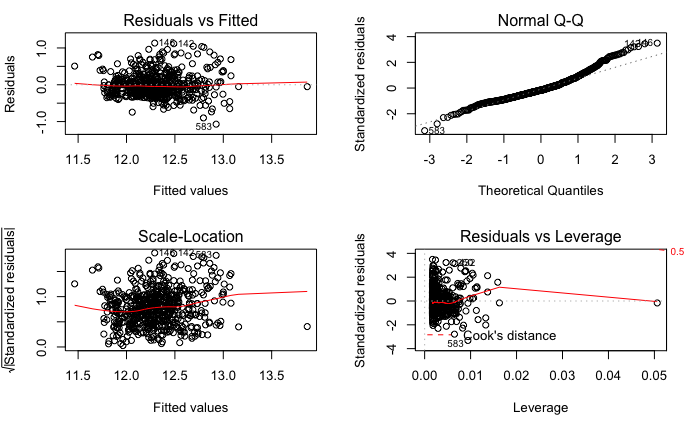

```r
par(mfrow=c(2,2)) # set 2 rows and 2 column plot layout
plot(model_2)
```

Let’s try adding one more variable.

```r
model_4 <- lm(logValue ~ MedianAge + nBedrooms + logKitchen, data = sd_trans_sub)
summary(model_4)
```

```
Call:
lm(formula = logValue ~ MedianAge + nBedrooms + logKitchen, data = sd_trans_sub)

Residuals:
     Min       1Q   Median       3Q      Max
-0.92926 -0.21212 -0.05406  0.14687  1.10324

Coefficients:
             Estimate Std. Error t value             Pr(>|t|)
(Intercept) 10.670725   0.072476 147.230 < 0.0000000000000002 ***
MedianAge    0.037460   0.002198  17.039 < 0.0000000000000002 ***
nBedrooms    0.134370   0.022113   6.076        0.00000000221 ***
logKitchen   0.217337   0.613599   0.354                0.723
---
Signif. codes:  0 ‘***’ 0.001 ‘**’ 0.01 ‘*’ 0.05 ‘.’ 0.1 ‘ ’ 1

Residual standard error: 0.3142 on 586 degrees of freedom
Multiple R-squared:  0.4824,    Adjusted R-squared:  0.4798
F-statistic: 182.1 on 3 and 586 DF,  p-value: < 0.00000000000000022
```

No increase to the Adj.R.SQ - It is not staitically significant

Add nRooms

```r
model_5 <- lm(logValue ~ MedianAge + nBedrooms + nRooms, data = sd_trans_sub)
summary(model_5)
```

```
Call:
lm(formula = logValue ~ MedianAge + nBedrooms + nRooms, data = sd_trans_sub)

Residuals:
     Min       1Q   Median       3Q      Max
-0.93672 -0.20422 -0.05589  0.13642  1.14786

Coefficients:
             Estimate Std. Error t value             Pr(>|t|)
(Intercept) 10.628213   0.072343 146.914 < 0.0000000000000002 ***
MedianAge    0.034869   0.002351  14.832 < 0.0000000000000002 ***
nBedrooms   -0.126399   0.090777  -1.392              0.16433
nRooms       0.157065   0.053879   2.915              0.00369 **
---
Signif. codes:  0 ‘***’ 0.001 ‘**’ 0.01 ‘*’ 0.05 ‘.’ 0.1 ‘ ’ 1

Residual standard error: 0.3119 on 586 degrees of freedom
Multiple R-squared:  0.4897,    Adjusted R-squared:  0.4871
F-statistic: 187.5 on 3 and 586 DF,  p-value: < 0.00000000000000022
```

- nBedrooms is no longer significant
  - Multicollinearity is occuring because its cofficient sign flipped.
  - Confirm multicollinearity with car::vif()

```r
library(car)
vif(model_5)
```

```
MedianAge nBedrooms    nRooms
 1.477458 24.726889 26.777931
```

# Spend ten minutes testing additional models

- summary()
- plot()

### Continue with model_3

```r
summary(model_3)
```

```
Call:
lm(formula = logValue ~ MedianAge + nBedrooms, data = sd_trans_sub)

Residuals:
     Min       1Q   Median       3Q      Max
-0.93116 -0.21283 -0.05542  0.14646  1.10212

Coefficients:
             Estimate Std. Error t value             Pr(>|t|)
(Intercept) 10.675934   0.070915 150.545 < 0.0000000000000002 ***
MedianAge    0.037570   0.002174  17.278 < 0.0000000000000002 ***
nBedrooms    0.131467   0.020523   6.406       0.000000000307 ***
---
Signif. codes:  0 ‘***’ 0.001 ‘**’ 0.01 ‘*’ 0.05 ‘.’ 0.1 ‘ ’ 1

Residual standard error: 0.3139 on 587 degrees of freedom
Multiple R-squared:  0.4823,    Adjusted R-squared:  0.4806
F-statistic: 273.5 on 2 and 587 DF,  p-value: < 0.00000000000000022
```

### Continue Assumption Checks

#### Multicollinearity

```r
vif(model_3)
```

```
MedianAge nBedrooms
 1.247934  1.247934
```

Values are less than 4, we can move on.

#### Correlation between residuals and independent variables

```r
# Test for significant correlation between residuals and MedianAge
cor.test(model_3$residuals, sd_trans_sub$MedianAge)

# Test for significant correlation between residuals and nBedrooms
cor.test(model_3$residuals, sd_trans_sub$nBedrooms)
```

[output not shown]

### Normality of residuals

- Can check with the normal Q-Q plot, histogram, or shapiro.test(model_3$residuals).
- Given the large sample size, it is possible to relax this assumption
  - i.e. we do not need to be extremely strict.

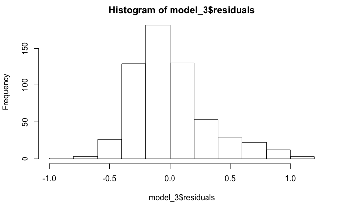

```r
hist(model_3$residuals)
```

```r
shapiro.test(model_3$residuals)
```

```
    Shapiro-Wilk normality test

data:  model_3$residuals
W = 0.94644, p-value = 0.00000000000008973
```

This is an acceptable amount of deviation from normal given the large sample size.

#### Auto-correlation of residuals

Geographical data often suffers from spatial auto-correlation of the residuals.

The steps for checking for spatial auto-correlation include:

1. Import spatial boundaries
   - data.frame is not geographical
2. Join data and residuals
3. Moran’s I calculation for residuals
4. If spatial-autocorrelation occurs, use a spatial-error or spatial-lag model

### Spatial Data in R

Spatial data can be stored in spatial data classes from the package.

- SpatialPoints or SpatialPointsDataFrame
- SpatialLines or SpatialLinesDataFrame
- SpatialPolygons or SpatialPolygonsDataFrame

For each of these, the first class is only able to store geometry. The second class, Spatial*DataFrame allows variables along with geometry.

```r
library(sp)
?SpatialPolygonsDataFrame
```

The polygon data is stored on the GitHub page and can be opened using: - rgdal::readOGR()

[output not shown]

[output cut: 52 more lines]

Data are stored in a geoJSON

```r
california_polygons <- readOGR(
  "https://raw.githubusercontent.com/gisUTM/GGR376/master/Lab_1/Tutorial/house_polygons.geojson")
```

Check the class (type) of the variable california_polygons

```r
class(california_polygons)
```

```
[1] "SpatialPolygonsDataFrame"
attr(,"package")
[1] "sp"
```

Plot the spatial boundaries

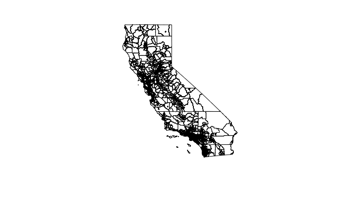

```r
plot(california_polygons)
```

Take a look at the data. It contains one variable GEOID, which can be used in joining the data and residuals.

```r
california_polygons@data
```

|  | GEOID |
| --- | --- |
| 0 | 6005000100 |
| 1 | 6011000100 |
| 2 | 6019000100 |
| 3 | 6023000100 |
| 4 | 6027000100 |
| 5 | 6031000100 |
| 6 | 6033000100 |
| 7 | 6043000100 |
| 8 | 6047000100 |
| 9 | 6049000100 |

[output cut: 990 more lines]

- Create a dataframe with the model residuals and the model input data

```r
model_3_dataframe <- cbind(sd_trans_sub, residuals = model_3$residuals)
model_3_dataframe
```

|  | GEOID | yearBuilt | nRooms | nBedrooms | MedianAge | logValue | logMobile | logPlumb | logKitchen | residuals |
| --- | --- | --- | --- | --- | --- | --- | --- | --- | --- | --- |
| 1 | 6073000100 | 1939 | 6.5 | 3.248525 | 46.9 | 13.27251 | 0.000000000 | 0.0000000000 | 0.004415018 | 0.4074458353 |
| 2 | 6073000200 | 1954 | 4.2 | 1.867992 | 39.9 | 12.80106 | 0.000000000 | 0.0032578142 | 0.006799731 | 0.3804842581 |
| 3 | 6073000300 | 1965 | 3.4 | 1.526083 | 39.4 | 12.61021 | 0.000000000 | 0.0027238696 | 0.004083027 | 0.2533678307 |
| 4 | 6073000400 | 1970 | 3.1 | 1.328351 | 33.9 | 12.64304 | 0.000000000 | 0.0000000000 | 0.000000000 | 0.5188332582 |
| 5 | 6073000500 | 1949 | 4.0 | 1.757085 | 37.7 | 12.67858 | 0.000000000 | 0.0046162806 | 0.006916454 | 0.3552377774 |
| 6 | 6073000600 | 1967 | 3.4 | 1.488033 | 37.4 | 12.33535 | 0.000000000 | 0.0098369936 | 0.002598079 | 0.0586535265 |
| 7 | 6073000700 | 1959 | 3.6 | 1.496124 | 39.0 | 12.73729 | 0.000000000 | 0.0153849188 | 0.014960741 | 0.3994196593 |
| 8 | 6073000800 | 1969 | 3.4 | 1.578563 | 36.9 | 12.28118 | 0.000000000 | 0.0000000000 | 0.000000000 | 0.0113723963 |
| 9 | 6073000900 | 1967 | 3.2 | 1.286722 | 32.4 | 11.88242 | 0.004480007 | 0.0086221195 | 0.004799241 | -0.1799530740 |
| 10 | 6073001000 | 1961 | 3.6 | 1.538837 | 33.0 | 12.13512 | 0.000000000 | 0.0037453227 | 0.008221272 | 0.0170539114 |

[output cut: 580 more lines]

- Join the new dataframe to the sp object using sp::merge()

|  | GEOID | yearBuilt | nRooms | nBedrooms | MedianAge | logValue | logMobile | logPlumb | logKitchen | residuals |
| --- | --- | --- | --- | --- | --- | --- | --- | --- | --- | --- |
| 1 | 6073000100 | 1939 | 6.5 | 3.248525 | 46.9 | 13.27251 | 0.000000000 | 0.0000000000 | 0.004415018 | 0.4074458353 |
| 2 | 6073000200 | 1954 | 4.2 | 1.867992 | 39.9 | 12.80106 | 0.000000000 | 0.0032578142 | 0.006799731 | 0.3804842581 |
| 3 | 6073000300 | 1965 | 3.4 | 1.526083 | 39.4 | 12.61021 | 0.000000000 | 0.0027238696 | 0.004083027 | 0.2533678307 |
| 4 | 6073000400 | 1970 | 3.1 | 1.328351 | 33.9 | 12.64304 | 0.000000000 | 0.0000000000 | 0.000000000 | 0.5188332582 |
| 5 | 6073000500 | 1949 | 4.0 | 1.757085 | 37.7 | 12.67858 | 0.000000000 | 0.0046162806 | 0.006916454 | 0.3552377774 |
| 6 | 6073000600 | 1967 | 3.4 | 1.488033 | 37.4 | 12.33535 | 0.000000000 | 0.0098369936 | 0.002598079 | 0.0586535265 |
| 7 | 6073000700 | 1959 | 3.6 | 1.496124 | 39.0 | 12.73729 | 0.000000000 | 0.0153849188 | 0.014960741 | 0.3994196593 |
| 8 | 6073000800 | 1969 | 3.4 | 1.578563 | 36.9 | 12.28118 | 0.000000000 | 0.0000000000 | 0.000000000 | 0.0113723963 |
| 9 | 6073000900 | 1967 | 3.2 | 1.286722 | 32.4 | 11.88242 | 0.004480007 | 0.0086221195 | 0.004799241 | -0.1799530740 |
| 10 | 6073001000 | 1961 | 3.6 | 1.538837 | 33.0 | 12.13512 | 0.000000000 | 0.0037453227 | 0.008221272 | 0.0170539114 |

[output cut: 580 more lines]

Map the residuals

```r
library(latticeExtra)
```

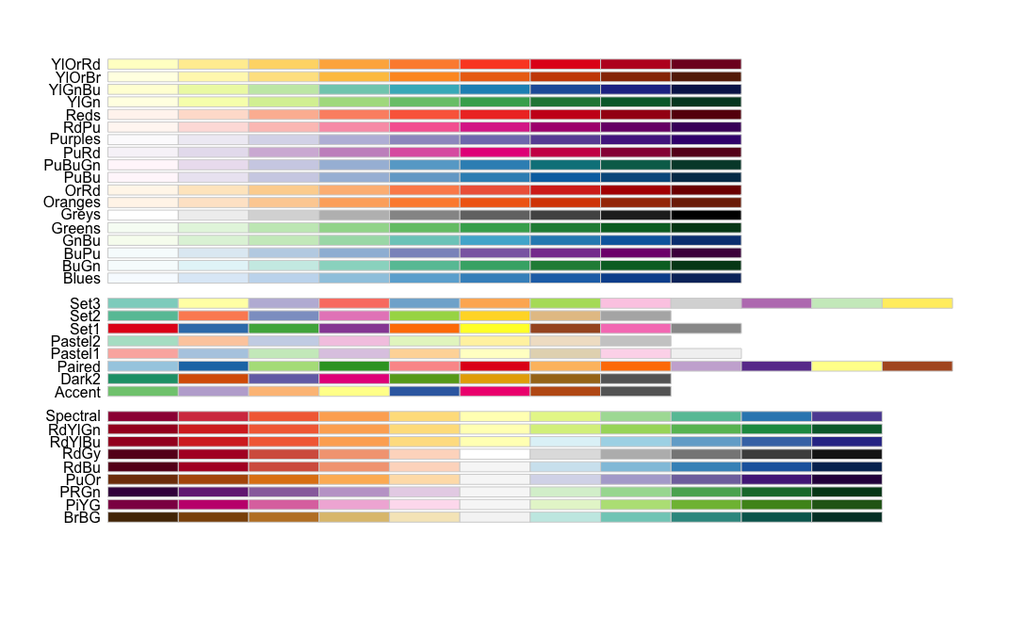

Create a colour palette to be used in our map with 7 colours (6 breaks)

```r
col_palette
```

```
[1] "#8C510A" "#D8B365" "#F6E8C3" "#F5F5F5" "#C7EAE5" "#5AB4AC" "#01665E"
```

Generate the map

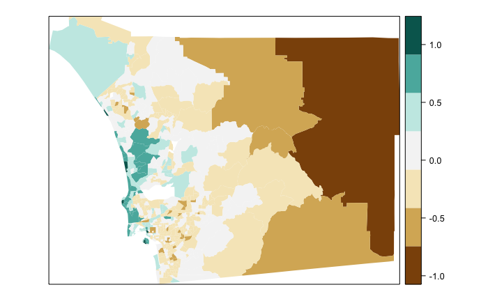

```r
spplot(california_spdf, "residuals",
       col.regions = col_palette, # The colour palette you just created
       cuts = 6, # Cuts is the number of colours - 1
       col = "transparent") # This sets the border colour, try changing to "black"
```

Spatial auto-correlation is suggested by this plot.

#### Confirm Spatial Auto-Correlation with Moran’s I

- Moran’s I requires spatial weights
  - Points: most often distances
  - Polygons: Neighbours or distances

Create a list of polygons that share borders with spdep::poly2nb() - It would be possible to add connections in this list - E.g. areas that do not physically touch by are connect by a bridge across a bay.

```r
library(spdep)
california_nb <- poly2nb(california_spdf)
california_nb
```

[output not shown]

Plot neighbour connections

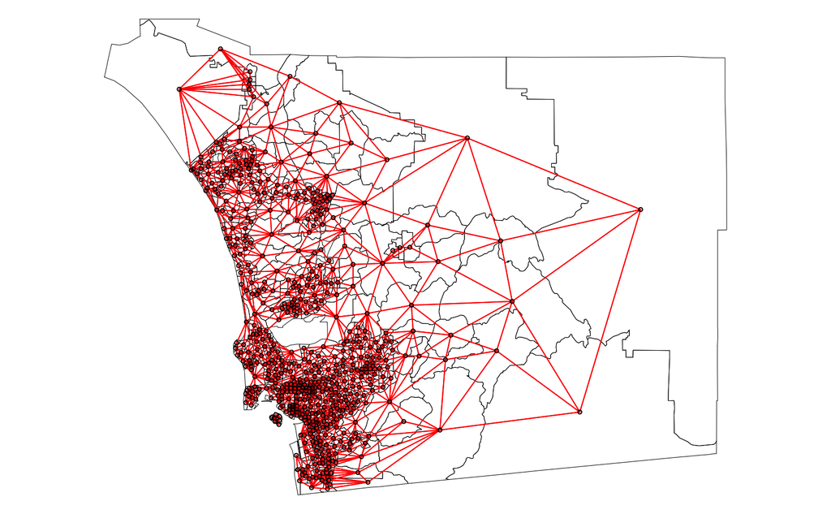

```r
par(mai=c(0,0,0,0))
plot(california_spdf)
plot(california_nb, coordinates(california_spdf), col='red', lwd=2, add=TRUE)
```

It is congested on the west coast, but this demonstrates the relationships stored in the neighbours list.

#### Moran’s I Calculation

1. The neighbours list must be changed to weights based on the number of neighbours.
   - If a polygon has 5 neighbours, each weight is 0.2.
2. moran.test()
   - sensitive to the form of the graph of neighbour relationships and other factors
   - best to check results with those of moran.mc()
3. moran.mc()

Convert Neigbours List to Spatial Weights

```r
california_listw <- nb2listw(california_nb)

print("View the neighbours for polygon 20")
california_listw$neighbours[[20]]

print("View the weights for polygon 20")
california_listw$weights[[20]]
```

[output not shown]

```r
moran.mc(california_spdf$residuals, california_listw, 999)
```

```
    Monte-Carlo simulation of Moran I

data:  california_spdf$residuals
weights: california_listw
number of simulations + 1: 1000

statistic = 0.52579, observed rank = 1000, p-value = 0.001
alternative hypothesis: greater
```

#### Spatial Regression

1. Spatial Lag
2. Spatial Error

#### Spatial Lag Model

spdep::lagsarlm()

```r
lag_model
```

```
Call:
lagsarlm(formula = logValue ~ MedianAge + nBedrooms, data = california_spdf,
    listw = california_listw)
Type: lag

Coefficients:
        rho (Intercept)   MedianAge   nBedrooms
 0.72534101  2.60686759  0.01669924  0.07800147

Log likelihood: 75.21558
```

Get more details with the summary function

```r
summary(lag_model)
```

```
Call:lagsarlm(formula = logValue ~ MedianAge + nBedrooms, data = california_spdf,     listw = california_listw)

Residuals:
      Min        1Q    Median        3Q       Max
-0.670579 -0.119756 -0.021773  0.097314  0.949977

Type: lag
Coefficients: (asymptotic standard errors)
             Estimate Std. Error z value              Pr(>|z|)
(Intercept) 2.6068676  0.3015759  8.6441 < 0.00000000000000022
MedianAge   0.0166992  0.0015041 11.1028 < 0.00000000000000022
nBedrooms   0.0780015  0.0138868  5.6169         0.00000001944

Rho: 0.72534, LR test value: 454.59, p-value: < 0.000000000000000222
Asymptotic standard error: 0.026744
    z-value: 27.121, p-value: < 0.000000000000000222
Wald statistic: 735.56, p-value: < 0.000000000000000222

Log likelihood: 75.21558 for lag model
ML residual variance (sigma squared): 0.040318, (sigma: 0.20079)
Number of observations: 590
Number of parameters estimated: 5
AIC: -140.43, (AIC for lm: 312.16)
LM test for residual autocorrelation
test value: 2.8858, p-value: 0.089361
```

Check the residuals for spatial auto-correlation.

- Add residuals from lag model to SpatialPolygonDataFrame

```r
moran.mc(california_spdf$lagResids, california_listw, 999)
```

```
    Monte-Carlo simulation of Moran I

data:  california_spdf$lagResids
weights: california_listw
number of simulations + 1: 1000

statistic = -0.029561, observed rank = 120, p-value = 0.88
alternative hypothesis: greater
```

#### Spatial Error Model

spdep::errorsarlm()

```r
error_model = errorsarlm(logValue ~ MedianAge + nBedrooms,
                     data = california_spdf,
                     listw = california_listw)
```

Check the error model residuals for spatial auto-correlation.

```r
# Add error model residuals to SpatialPolygonDataFrame
california_spdf$errorResids <- residuals(error_model)
# Moran's I
moran.mc(california_spdf$errorResids, california_listw, 999)
```

```
    Monte-Carlo simulation of Moran I

data:  california_spdf$errorResids
weights: california_listw
number of simulations + 1: 1000

statistic = -0.089284, observed rank = 1, p-value = 0.999
alternative hypothesis: greater
```

#### One last plot of the residuals

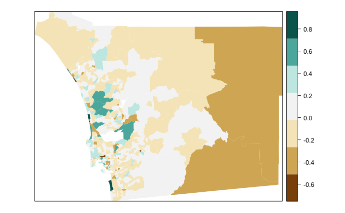

```r
spplot(california_spdf, "errorResids",
       col.regions = col_palette, # The colour palette you just created
       cuts = 6, # Cuts is the number of colours - 1
       col = "transparent")
```

## Lagrange Multiplier diagnostics

You would run this test prior to selecting the error or lag model.

```r
summary(lanDiag)
```

```
    Lagrange multiplier diagnostics for spatial dependence
data:
model: lm(formula = logValue ~ MedianAge + nBedrooms, data = sd_trans_sub)
weights: california_listw

       statistic parameter               p.value
LMerr    483.341         1 < 0.00000000000000022 ***
LMlag    552.118         1 < 0.00000000000000022 ***
RLMerr    35.312         1         0.00000000281 ***
RLMlag   104.088         1 < 0.00000000000000022 ***
SARMA    587.429         2 < 0.00000000000000022 ***
---
Signif. codes:  0 ‘***’ 0.001 ‘**’ 0.01 ‘*’ 0.05 ‘.’ 0.1 ‘ ’ 1
```

In this example, it is not very helpful as they are both significant. A theoretical underpinning should be applied to select the model.